# Part II - Prosper Loan Data Visualization.

## by Daniel Okello

## Investigation Overview

In this investigation, I wanted to gain insights on how the loan borrower characteristics and loan terms relate with interest rates of the Prosper loans. For the purposes of this presentation, I will restrict the features of focus to the original loan amount, the interest rate and the employment status of the loan borrowers.

## Dataset Overview

The Prosper dataset contains over 113,937 loans issued by Prosper between 2005 and 2014. The dataset presents over 81 columns, all of which provide different insights depending on the research question.

From this dataset however, I was able to extract only 7 features, i.e. Listing creation date, original loan amount, upper credit score range, lower credit score range, borrower rate, loan term and employment status.

## Distribution of interest rates amoung the loan borrowers.

An edge peak distribution of interest rates is observed. A relatively normal plot is observed with bimodal peaks at 15% and 16% per anum, along with a spike in interest rates 32% per anum.

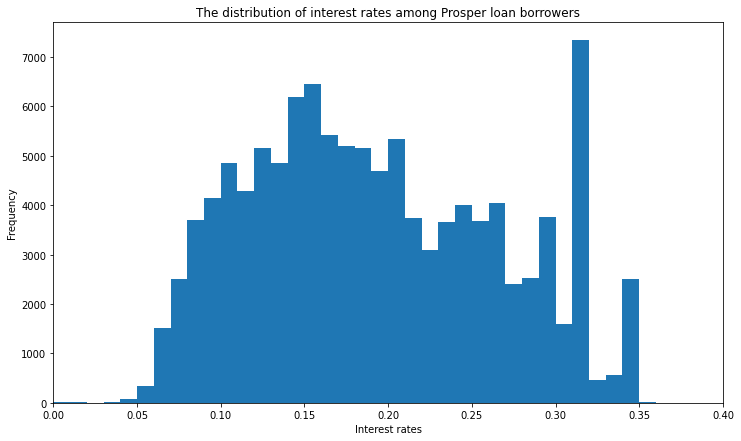

## Most common employment statuses amoung the borrowers.

Most loan borrowers are employed followed by Full-time borrowers, while the non employed are the least loan borrowers.

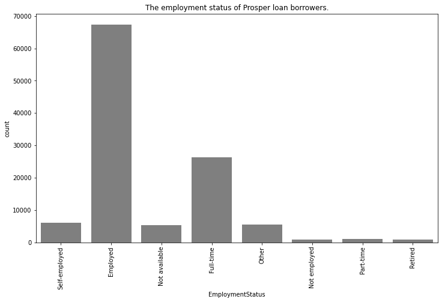

## Interest rate vs loan original amount.

The regression plot further solidifies facts from the previous plot. A negative incline line, the regression line shows that there is a negative relationship between the Loan original amount and the intereest rate.

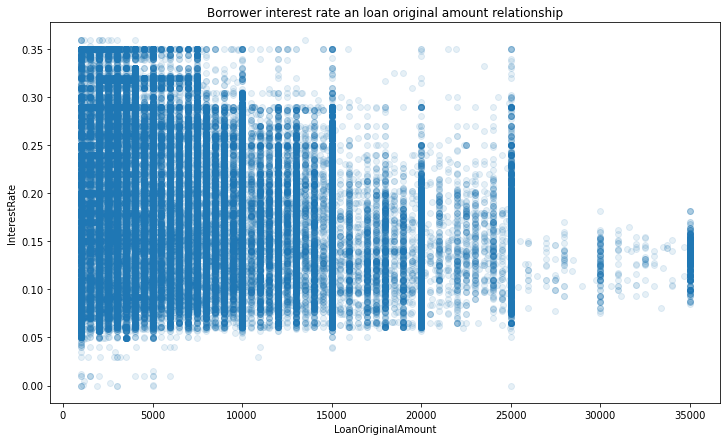

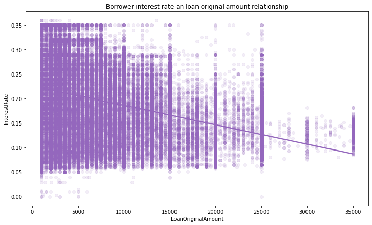

## Interest rate variation by Employment status.

Loan borrowers who are unemployed on average have loans with the highest interest rates, while those who are full-time employed have loans with lower interest rates.

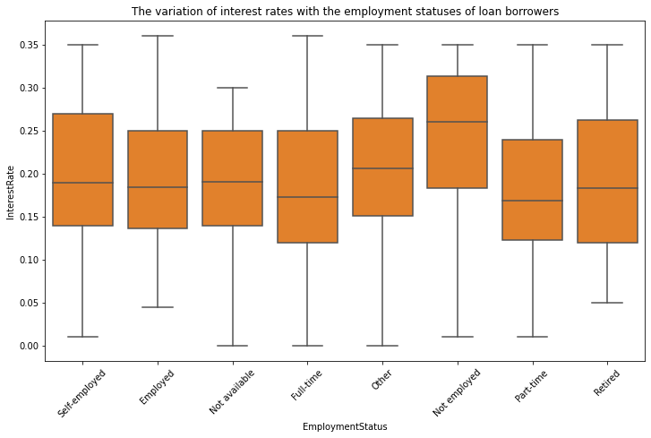

## Loan Original Amount vs Interest Rate vs Employment Status of the loan borrowers.

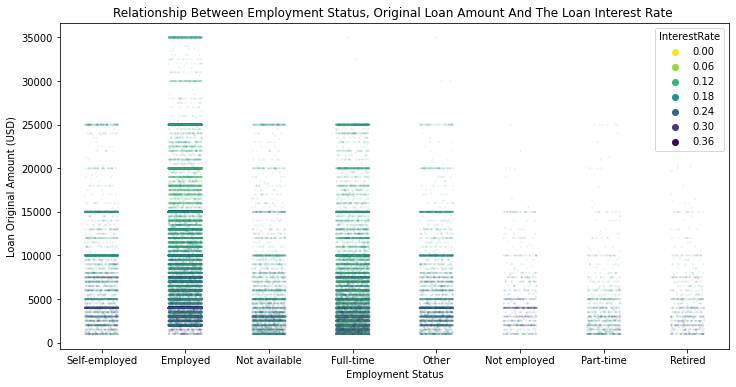